# R Markdown

Applied Machine Learning in Economics

Open a new markdown:

[figure not shown]

Explore around what types of markdowns you can make. Then select an html document. Knit this document by typing `Ctrl-Shift-k`

Now you may follow this document

# 1 Section 1

## 1.1 This will one.one

### 1.1.1 not 1.1.2

#### 1.1.1.1 Not in table of contents

# 2 RMarkdown Basics

Here are some fundamentals to writting in RMarkdown.

## 2.1 Writing text

This is how to write text in RMarkdwon. Notice writing on the next line stays in the same paragraph.

This is how you start a new paragraph. Wrap you words in * to get *italics*. Using two *s will produce **bolface**. There are other things that we can do too, like making lists.

1. Item 1
2. Item 2
   2. Notice how we had to align in the RMarkdown code
      - You can choose whether you use numers. or letters. but RMarkdown chooses the symbols for you :(

This is how we reference inline code like `R`’s base function `plot` is as pretty as `ggplot2`’s function `ggplot`.

To write math, we can use some limited `latex` features. Like if we wanted to show a regression formula inline: $y_i = \alpha + x_i\beta + \epsilon_i$. Alternatively, if we have important math like the geometric series identity, we can make it stand out:
$$2^2 = 4\\
\begin{align*}
\sum_{n=0}^\infty ar^n & = a \left( \frac{1}{1-r} \right)\\
& = \frac{a}{1-r}\\
& \text{for } |r| < 1
\end{align*}$$

If we want to link sections, we do this Section 1. Or if we need to link a website, we do this while making sure to include https. A really useful resource for additional RMarkdown tips and tricks.

This is how we include images in our markdown.

[figure not shown]

## 2.2 Writing Code

Here is the basic to writing code chunks.

```r
print('hello world')
```

```
## [1] "hello world"
```

The first part of the curly braces tells you what language you are using and the name of the chunk. Then options can be set up using commas after the chunk name by setting them to `TRUE` or `FALSE`. Some major options all of which have default of `TRUE` are:

- `include` - Whether or not to be included in the document
- `echo` - Displays the code
- `results` - Displays the output of the code
- `messages` - Display messages from the functions if they have them.

# 3 An example assignment

We must do the following:

1. load ggplot2
2. load in gapminder_2007
3. produce a correlation matrix
4. obtain mean and standard deviation of the America’s GDPc
5. Summary stats of life expectancy for countries with GDPC less than $10,000
6. Replicate plot from last lecture

## 3.1 Load in ggplot2 and gapminder_2007

Done, but I am not going to show you!

## 3.2 Produce Three Sets of Statistics

Here is a correlation matrix GDP per capita, life expectancy, and population.

```
##            gdpPercap    lifeExp         pop
## gdpPercap  1.0000000 0.67866240 -0.05567560
## lifeExp    0.6786624 1.00000000  0.04755312
## pop       -0.0556756 0.04755312  1.00000000
```

Here is the mean and standard deviation of the America’s GDP per capita.

```r
americas = gm[gm$continent == 'Americas', ]
m = mean(americas$gdpPercap)
m = round(m, 2)
s = round(sd(gm[gm$continent == 'Americas', 'gdpPercap']), 2)
print(paste0("Americas' mean: ", m))
```

```
## [1] "Americas' mean: 11003.03"
```

```r
print(paste("Americas' standrad deviation:", s))
```

```
## [1] "Americas' standrad deviation: 9713.21"
```

And finally here are the summary statistics of life expectancy for countries with less than $10,000 gdp per capita

```r
summary(gm[gm$gdpPercap < 10000, 'lifeExp'])
```

```
##    Min. 1st Qu.  Median    Mean 3rd Qu.    Max.
##   39.61   52.11   62.88   61.37   71.97   78.78
```

## 3.3 Replicate Last Lectures Plot

Here is the plot we already made.

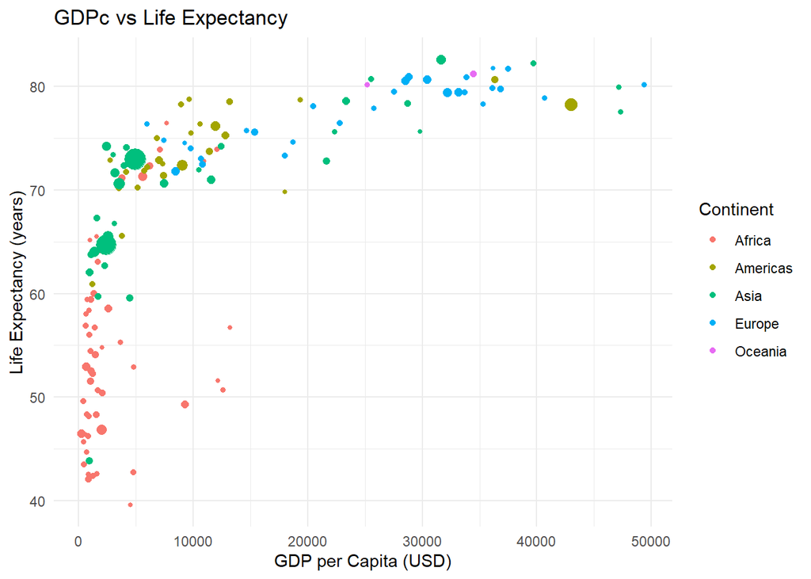